# UNIVARIATE ANALYSIS

## Section 1: Analysis of continuous outcomes

If we have a continuous outcome such as BMI, blood pressure, survey score, or gene expression and we want to perform some sort of statistical test, an important consideration is whether we should use the standard parametric tests like t-tests or ANOVA vs. a non-parametric test.

```
Some of the most common statistical tests and their non-parametric analogs:
```

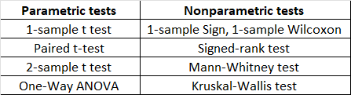

## A. Parametric tests

### T-test

**Assumptions of t-test**

```
1.The one sample t-test has two main assumptions
      -Independence of observations
      -Data are drawn from a normal distribution
2.The two sample t-test with equal variance has the additional assumption of equal variance in the two groups
```

#### 1. One sample t-test (Example Exercise)

```
Based on your prior knowledge, we know that the general population has a mean score on the mental composite summary (MCS) for the SF-36 of 50 units.  We would like to estimate the mean MCS score (variable name in the dataset: mcs).  Note that the MCS does not have units, so we will just use the term “units” to remind ourselves to report units in our analysis.
```

Load MSQOL dataset into R from folder : Data

```r
msqol= read.csv("Data/MSQOL.csv")
```

R will allow us to calculate our summary statistics, confidence interval and p-value using a single command, t.test. For the one sample t-test, we need to specify the variable of interest as well as the value for the null hypothesis, 50

```r
t.test(msqol$mcs,mu=50)
```

```
	One Sample t-test

data:  msqol$mcs
t = -1.228, df = 250, p-value = 0.2206
alternative hypothesis: true mean is not equal to 50
95 percent confidence interval:
 48.14726 50.42966
sample estimates:
mean of x
 49.28846
```

The output presented here provides the sample mean (49.3 units). The output also presents the 95% confidence interval for the mean (48.1, 50.4). In addition to this information, R provides the two-sided alternative hypothesis, which corresponds to the p-value (p=0.22).

With this information, we can complete our hypothesis test.

1. State estimate: 49.3 units
2. Calculate confidence interval and p-value (stat package): 95% CI: 48.1, 50.4; p=0.22
3. The estimated mean MCS score was 49.3 units, and the range of plausible values is from 48.1 to 50.4 units. The mean in the normal population (50) is included in the confidence interval

#### 2. Two sample t-test (Example Exercise)

Another question of interest based on this initial dataset is whether the mental quality of life as measured by MCS is different in male vs.female RRMS patients. We assume that the male and female RRMS patients in our study represent a random sample of the male and female RRMS patients.

For the two sample t-test, we need to specify the outcome variable as well as the group variable. Note that the default in R is to fit an unequal variance t-test.

```r
t.test(msqol$mcs~msqol$male)
```

```
	Welch Two Sample t-test

data:  msqol$mcs by msqol$male
t = 1.5371, df = 93.824, p-value = 0.1276
alternative hypothesis: true difference in means between group 0 and group 1 is not equal to 0
95 percent confidence interval:
 -0.6150422  4.8314837
sample estimates:
mean in group 0 mean in group 1
       49.77562        47.66740
```

The output presented here provides the means in the two groups, from which you can calculate the difference (49.8-47.7 = 2.1 units). The output also presents the 95% confidence interval for the difference in the mean (-0.62, 4.83). In addition to this information, R provides the two-sided alternative hypothesis, which corresponds to the p-value (p=0.13).

With this information, we can complete our analysis.

```
1) State estimate: x_females-x_males=2.1 units
2) Calculate confidence interval and p-value (stat package): 95% CI: -0.6, 4.8; p=0.13
3) The estimated difference in mean MCS score comparing females to males was 2.1 units, and the range of plausible values is from -0.6 to 4.8 units.The confidence interval includes values showing that males have a slightly higher MCS score or females have higher MCS scores.
```

If we had completed the analysis assuming equal variances

```r
t.test(msqol$mcs~msqol$male,var.equal=T)
```

```
	Two Sample t-test

data:  msqol$mcs by msqol$male
t = 1.5378, df = 249, p-value = 0.1254
alternative hypothesis: true difference in means between group 0 and group 1 is not equal to 0
95 percent confidence interval:
 -0.5918038  4.8082453
sample estimates:
mean in group 0 mean in group 1
       49.77562        47.66740
```

### ANOVA (Analysis of Variance)

```
A statistical method used to analyze the differences between the means of two or more groups or treatments. It is often used to determine whether there are any statistically significant differences between the means of different groups.
```

**Types of ANOVA:**

1. One-way (for comparing means of groups)
2. Two-way (for examining effects of two independent variables on a dependent variable)

**Assumption of ANOVA**

```
1. The population from which samples are drawn should be normally distributed.
2. Independence of cases: the sample cases should be independent of each other.
3. Homogeneity of variance: Homogeneity means that the variance among the groups should be approximately equal.
```

#### 1. One way ANOVA (Example Exercise)

we were interested in the impact of four different diets (Diet 1, Diet 2, Diet 3, Diet 4) on the weight (in grams) of mice. In all, 40 mice (10 per group) contributed to our experiment. Our null hypothesis is that the mean in each of the groups will be the same, and our alternative hypothesis is that at least one of the groups is different. Since we have a continuous outcome with a categorical predictor, we will analyze this data using one way ANOVA.

load the diet dataset into R from folder: Data

```r
diet= read.csv("Data/diet.csv")
```

Now, we will summarize and graph the data to ensure that we do not have any outliers or data entry issues. To do this, we will use the by and boxplot commands.

```r
by(diet$weight, diet$diet, summary)
```

```
diet$diet: 1
   Min. 1st Qu.  Median    Mean 3rd Qu.    Max.
  20.00   24.25   25.50   25.40   27.75   29.00
------------------------------------------------------------
diet$diet: 2
   Min. 1st Qu.  Median    Mean 3rd Qu.    Max.
  17.00   19.50   23.00   22.30   24.75   28.00
------------------------------------------------------------
diet$diet: 3
   Min. 1st Qu.  Median    Mean 3rd Qu.    Max.
  16.00   17.25   20.00   19.90   21.75   25.00
------------------------------------------------------------
diet$diet: 4
   Min. 1st Qu.  Median    Mean 3rd Qu.    Max.
  16.00   18.00   20.00   19.80   20.75   24.00
```

If we would like to calculate the standard deviation in each group, we could use the same by command, but we would change the function to sd.

```r
by(diet$weight, diet$diet, sd)
```

```
diet$diet: 1
[1] 2.836273
------------------------------------------------------------
diet$diet: 2
[1] 3.529243
------------------------------------------------------------
diet$diet: 3
[1] 2.923088
------------------------------------------------------------
diet$diet: 4
[1] 2.699794
```

The following command graphs the weight data by diet:

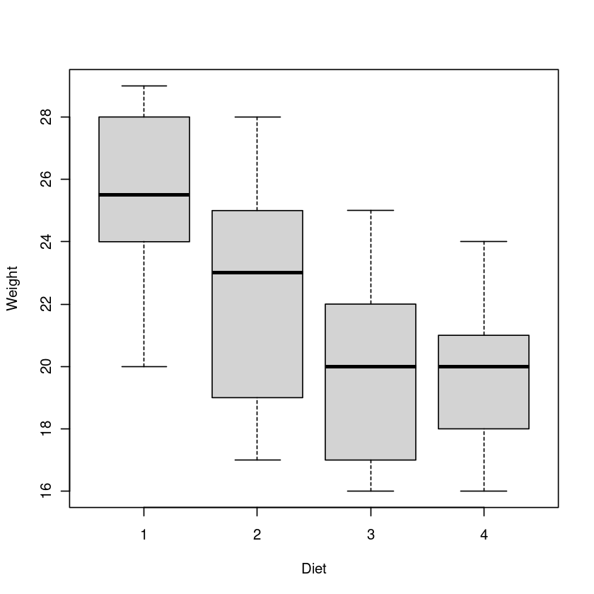

```r
boxplot(diet$weight~diet$diet, xlab="Diet", ylab="Weight")
```

Since there are no obvious outliers or other issues with the data, we will proceed to complete our analysis.

```r
summary(aov(diet$weight~factor(diet$diet)))
```

```
                  Df Sum Sq Mean Sq F value   Pr(>F)
factor(diet$diet)  3  208.1   69.37   7.637 0.000448 ***
Residuals         36  327.0    9.08
---
Signif. codes:  0 ‘***’ 0.001 ‘**’ 0.01 ‘*’ 0.05 ‘.’ 0.1 ‘ ’ 1
```

The p-value is 0.0004, which is less than 0.05. Therefore, we reject the null hypothesis and conclude that at least one of the means is different.

**An alternative approach to perform a one way ANOVA:**

```r
anova(lm(diet$weight~factor(diet$diet)))
```

A anova: 2 × 5

|  | Df <int> | Sum Sq <dbl> | Mean Sq <dbl> | F value <dbl> | Pr(>F) <dbl> |
| --- | --- | --- | --- | --- | --- |
| factor(diet$diet) | 3 | 208.1 | 69.366667 | 7.636697 | 0.0004476189 |
| Residuals | 36 | 327.0 | 9.083333 | NA | NA |

Since we found that at least one group is significantly different, we would like to complete the pairwise comparisons. In order to correct for multiple comparisons, we can use a Bonferroni correction. To complete pairwise comparisons with a Bonferroni correction, we can use the pairwise.t.test command:

```r
pairwise.t.test(diet$weight,diet$diet, p.adj = "bonf")
```

```
	Pairwise comparisons using t tests with pooled SD

data:  diet$weight and diet$diet

  1      2      3
2 0.1641 -      -
3 0.0014 0.5005 -
4 0.0011 0.4310 1.0000

P value adjustment method: bonferroni
```

The table provides the pairwise group comparisons with Bonferroni adjusted p-values. For example, the comparison of Diet 4 and Diet 1 has a p-value of 0.001. Recall that the mean weight for Diet 1 is 25.4, while the mean weight for Diet 4 is 19.8. This pairwise comparison shows that Diet 1 leads to a higher weight.

Based on the results above, we can say that mice on Diets 3 and 4 were lighter than mice on Diet 1 (p=0.001 for each comparison), but the remaining pairwise comparisons did not have p-values less than 0.05.

## B. Non-Parametric Test

Methods of statistical analysis that do not require a distribution to meet the required assumptions to be analyzed (especially if the data is not normally distributed). Preferrred when the distribution of the sample is skewed toward one side or the distribution is unknown due to the small sample size.

### One-sample Wilcoxon test (Alternative to one sample T-test)

```r
wilcox.test(msqol$mcs,mu=50,conf.int=T)
```

```
	Wilcoxon signed rank test with continuity correction

data:  msqol$mcs
V = 16403, p-value = 0.6087
alternative hypothesis: true location is not equal to 50
95 percent confidence interval:
 49.02042 51.45562
sample estimates:
(pseudo)median
      50.31884
```

### Wilcoxon rank sum test/ Mann-Whitney test (Alternative to two sample T-test)

```r
wilcox.test(msqol$mcs~msqol$male,conf.int=T)
```

```
	Wilcoxon rank sum test with continuity correction

data:  msqol$mcs by msqol$male
W = 6448, p-value = 0.0794
alternative hypothesis: true location shift is not equal to 0
95 percent confidence interval:
 -0.2678348  4.6513975
sample estimates:
difference in location
              2.147744
```

### Kruskal-Wallis test (Alternative to one way ANOVA)

```r
kruskal.test(diet$weight~factor(diet$diet))
```

```
	Kruskal-Wallis rank sum test

data:  diet$weight by factor(diet$diet)
Kruskal-Wallis chi-squared = 14.885, df = 3, p-value = 0.001918
```

### Pairwise Wilcox test (Multiple pair-wise comparison)

```r
pairwise.wilcox.test(diet$weight,diet$diet, p.adj = "bonf",exact = FALSE)
```

```
	Pairwise comparisons using Wilcoxon rank sum test with continuity correction

data:  diet$weight and diet$diet

  1      2      3
2 0.2865 -      -
3 0.0144 0.7721 -
4 0.0084 0.6082 1.0000

P value adjustment method: bonferroni
```

## Section 2: Analysis of proportions

### Confidence intervals for a single proportion

```
We would like to estimate the proportion of RRMS patients with fatigue scores of at least 40.  To calculate a confidence interval for this proportion, we will dichotomize fatigue using 40 as the cut-off.  First, we will create a new variable called “fatiglevel”.  We will assign fatiglevel=0 if fatigue score is less than 40 and fatiglevel=1 if fatigue score is greater than or equal 40.
```

```r
msqol$fatiglevel<-ifelse(msqol$fatig>=40,1,0)

# Now, we can calculate the sample proportion, which is our point estimate of the population proportion.

table(msqol$fatiglevel)/sum(table(msqol$fatiglevel))
```

```
        0         1
0.8253968 0.1746032
```

The estimated proportion of patients with fatigue score greater than or equal to 40 is 0.1746.

To calculate the exact binomial confidence interval for the proportion:

```r
binom.test(x=table(msqol$fatiglevel)[2],n=sum(table(msqol$fatiglevel)))
```

```
	Exact binomial test

data:  table(msqol$fatiglevel)[2] and sum(table(msqol$fatiglevel))
number of successes = 44, number of trials = 252, p-value < 2.2e-16
alternative hypothesis: true probability of success is not equal to 0.5
95 percent confidence interval:
 0.1298262 0.2272180
sample estimates:
probability of success
             0.1746032
```

The estimated proportion is the same as above (0.1746032) and the 95% confidence interval is shown as well (0.1298262 - 0.2272180). Note that a hypothesis test for the null hypothesis that the true probability of success is equal to 0.5 is also provided. Often, this hypothesis test is not of interest so be careful interpreting this p-value. You can change the null hypothesis to be 0.2 by adding “p=0.2” to the end of the command.

Other Cofidence internval: Wilson confidence interval:

```r
prop.test(x=table(msqol$fatiglevel)[2],n=sum(table(msqol$fatiglevel)), correct=F)
```

```
	1-sample proportions test without continuity correction

data:  table(msqol$fatiglevel)[2] out of sum(table(msqol$fatiglevel)), null probability 0.5
X-squared = 106.73, df = 1, p-value < 2.2e-16
alternative hypothesis: true p is not equal to 0.5
95 percent confidence interval:
 0.1327152 0.2262628
sample estimates:
        p
0.1746032
```

### Two sample test of proportions

To we investigated the effect of a single nucleotide polymorphism on the probability of disease progression in patients with multiple sclerosis. The dataset for this analysis is the 2x2table.csv dataset. In this dataset, we have the variable snp that equals 1 for patients with the SNP and 0 for patients without the SNP, and we have the variable prog that equals 1 for patients who progressed and 0 for patients who failed to progress.

```r
snp_data= read.csv("Data/2x2table.csv")

table(snp_data$snp, snp_data$prog)
```

```
      0   1
  0 103  13
  1  62  12
```

Of those patients without the SNP, 13 progressed, and 103 failed to progress. Of those patients with the SNP, 12 progressed, and 62 failed to progress.

```r
#table of the row proportions (the option 1 gives row proportions, while 2 gives column proportions, and the default gives total sample proportions):
prop.table(table(snp_data$snp, snp_data$prog),1)
```

```
            0         1
  0 0.8879310 0.1120690
  1 0.8378378 0.1621622
```

Of those patients without the SNP, 0.11 progressed, and 0.89 failed to progress. Of those patients with the SNP, 0.16 progressed, and 0.84 failed to progress.

```r
#Hypothesis test in R.  The first is to complete a test of proportions using the prop.test command. This test provides you with the summary statistics as well as the p-value for the hypothesis test. The correct=FALSE option specifies that we are not using the continuity correction in our test. The default uses the continuity correction.

prop.test(table(snp_data$snp, snp_data$prog),correct=FALSE)
```

```
	2-sample test for equality of proportions without continuity
	correction

data:  table(snp_data$snp, snp_data$prog)
X-squared = 0.99215, df = 1, p-value = 0.3192
alternative hypothesis: two.sided
95 percent confidence interval:
 -0.0516337  0.1518201
sample estimates:
   prop 1    prop 2
0.8879310 0.8378378
```

The output presented here provides the sample proportions in each group. R reports the proportion that failed to progress (coded 0) rather than the proportion that progressed (coded 1).

The estimated difference in the proportion who failed to progress is q(SNP-)-q(SNP+)=0.89-0.84=0.05. Note that we use the notation q for the proportion who failed to progress as opposed to p which represented the proportion who progressed. The output also presents the Wald 95% confidence interval for the difference of the proportions (proportion that failed to progress in SNP- minus proportion that failed to progress in SNP+). In addition to this information, R provides the direction of the alternative hypothesis. Finally, R provides the two-sided hypothesis test p-value (p=0.32).

```r
#If we wanted to report the proportion who progressed in the two groups we could use this command:

prop.test(table(snp_data$snp,(1-snp_data$prog)),correct=F)
```

```
	2-sample test for equality of proportions without continuity
	correction

data:  table(snp_data$snp, (1 - snp_data$prog))
X-squared = 0.99215, df = 1, p-value = 0.3192
alternative hypothesis: two.sided
95 percent confidence interval:
 -0.1518201  0.0516337
sample estimates:
   prop 1    prop 2
0.1120690 0.1621622
```

```r
# Chi-square test

chisq.test(x=snp_data$snp, y=snp_data$prog, correct=FALSE)

# Fisher’s exact test

fisher.test(table(snp_data$prog, snp_data$snp))
```

```
	Pearson's Chi-squared test

data:  snp_data$snp and snp_data$prog
X-squared = 0.99215, df = 1, p-value = 0.3192
```

```
	Fisher's Exact Test for Count Data

data:  table(snp_data$prog, snp_data$snp)
p-value = 0.3803
alternative hypothesis: true odds ratio is not equal to 1
95 percent confidence interval:
 0.596721 3.896397
sample estimates:
odds ratio
  1.529888
```

```r
# Estimates of association: In order to calculate other estimates of the association when we have a dichotomous predictor and a dichotomous outcome.

library(epitools)

#To calculate risk ratio, we can use this command:

riskratio(x=snp_data$snp,y=snp_data$prog)
```

**$data**

A matrix: 3 × 3 of type int

|  | 0 | 1 | Total |
| --- | --- | --- | --- |
| 0 | 103 | 13 | 116 |
| 1 | 62 | 12 | 74 |
| Total | 165 | 25 | 190 |

**$measure**

A matrix: 2 × 3 of type dbl

|  | estimate | lower | upper |
| --- | --- | --- | --- |
| 0 | 1.000000 | NA | NA |
| 1 | 1.446985 | 0.6984203 | 2.997861 |

**$p.value**

A matrix: 2 × 3 of type dbl

|  | midp.exact | fisher.exact | chi.square |
| --- | --- | --- | --- |
| 0 | NA | NA | NA |
| 1 | 0.3303927 | 0.3802594 | 0.3192177 |

**$correction**

FALSE

From this set of results, we get both the chi-squared test p-value and Fisher’s exact test p-value. Further, we get the estimated risk ratio and the associated 95% confidence interval.

```r
#To calculate odds ratio, we can use this command:

oddsratio(x=snp_data$snp,y=snp_data$prog, method="wald")
```

**$data**

A matrix: 3 × 3 of type int

|  | 0 | 1 | Total |
| --- | --- | --- | --- |
| 0 | 103 | 13 | 116 |
| 1 | 62 | 12 | 74 |
| Total | 165 | 25 | 190 |

**$measure**

A matrix: 2 × 3 of type dbl

|  | estimate | lower | upper |
| --- | --- | --- | --- |
| 0 | 1.000000 | NA | NA |
| 1 | 1.533499 | 0.6583953 | 3.571743 |

**$p.value**

A matrix: 2 × 3 of type dbl

|  | midp.exact | fisher.exact | chi.square |
| --- | --- | --- | --- |
| 0 | NA | NA | NA |
| 1 | 0.3303927 | 0.3802594 | 0.3192177 |

**$correction**

FALSE

From this set of results, we get both the chi-squared test p-value and Fisher’s exact test p-value.Further, we get the estimated odds ratio and the associated 95% confidence interval.